# ggplot_exercise

Park, Soomin

2019년 6월 10일

## ggplot practice

#### 1. mpg 데이터의 cty(도시 연비)와 hwy(고속도로 연비) 간에 어떤 관계가 있는지 알아보려고 합니다. x축은 cty, y축은 hwy로 된 산점도를 만들어 보세요.

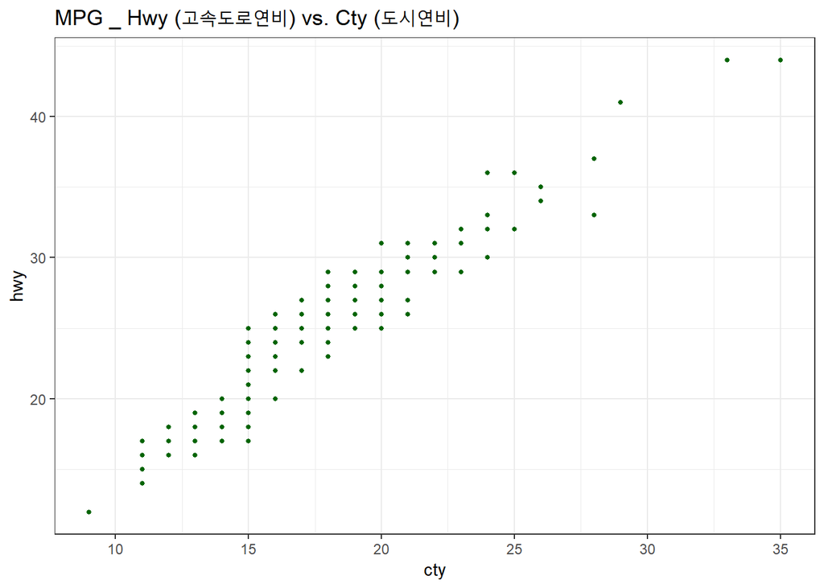

```r
ggplot(mpg, aes(x=cty, y=hwy)) +
  geom_point(size=1, colour='darkgreen')+
  labs(title = "MPG _ Hwy (고속도로연비) vs. Cty (도시연비)", size = 14) +
  theme_bw ()
```

#### 2. 미국 지역별 인구통계 정보를 담은 ggplot2 패키지의 midwest 데이터를 이용해서 전체 인구와 아시아인 인구 간에 어떤 관계가 있는지 알아보려고 합니다. x축은 poptotal(전체 인구), y축은 popasian(아시아인 인구)으로 된 산점도를 만들어 보세요. 전체 인구는 50만 명 이하, 아시아인 인구는 1만 명 이하인 지역만 산점도에 표시되게 설정하세요.

- options(scipen = 10) : do not abbreviate zeros up to 10 digits

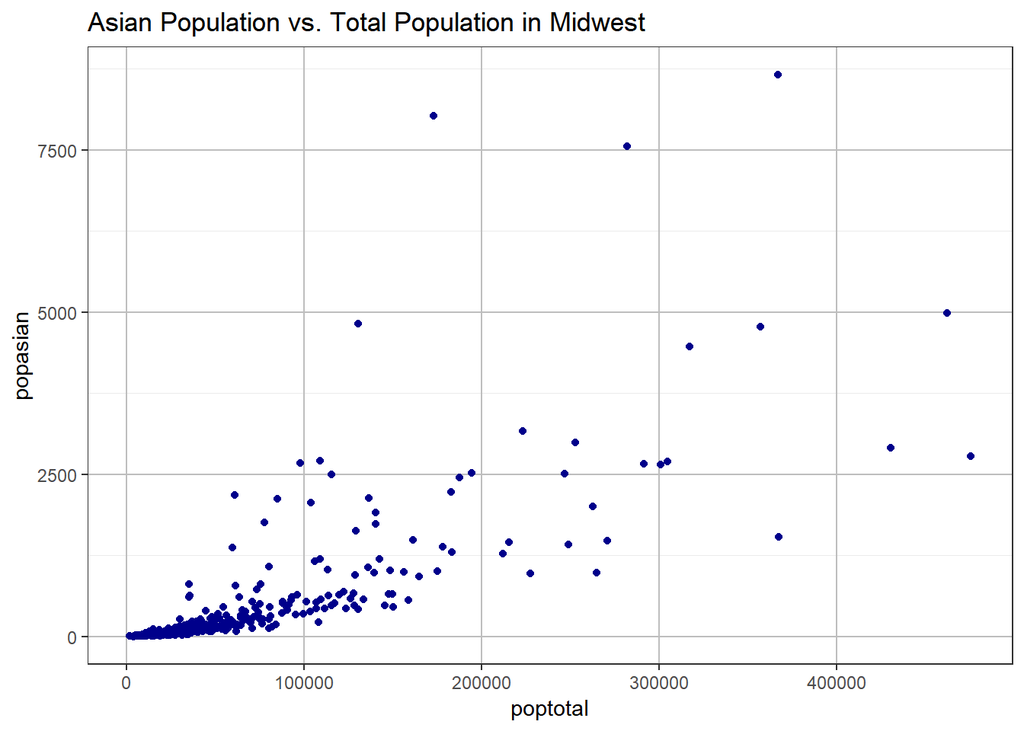

```r
midwest_1 <- midwest %>%
  filter (popasian <= 10000) %>%
  filter (poptotal <= 500000)
options (scipen = 10)
ggplot(midwest_1, aes(x=poptotal, y=popasian)) +
  geom_point(colour = 'darkblue') +
  labs(title = "Asian Population vs. Total Population in Midwest", size=14) +
  theme_bw () +
  theme(panel.grid.major.x = element_line(colour='grey'),
        panel.grid.major.y = element_line(colour='grey'),
        panel.grid.minor.x = element_blank())
```

#### 3. 어떤 회사에서 생산한 “suv” 차종의 도시 연비가 높은지 알아보려고 합니다. “suv” 차종을 대상으로 평균 cty(도시 연비)가 가장 높은 회사 다섯 곳을 막대 그래프로 표현해 보세요. 막대는 연비가 높은 순으로 정렬하세요.

```r
suv <- mpg %>%
  group_by(manufacturer)  %>%
  filter (class == 'suv') %>%
  summarise (mean_cty = mean(cty)) %>%
  arrange(desc(mean_cty)) %>%
  head(5)

suv_1 <- sqldf("select manufacturer, avg(cty) as Avg_cty from mpg
      group by manufacturer
      order by avg(cty) desc
      limit 0,5")
```

- geom_bar(stat=‘identity’) = geom_col()

[figure not shown]

```r
ggplot(suv_1, aes(x= reorder(manufacturer, -Avg_cty), y=Avg_cty, fill = manufacturer)) +
  geom_bar(stat='identity') +
  ggtitle("Avg Cty of SUV for top 5 manufacturers")
```

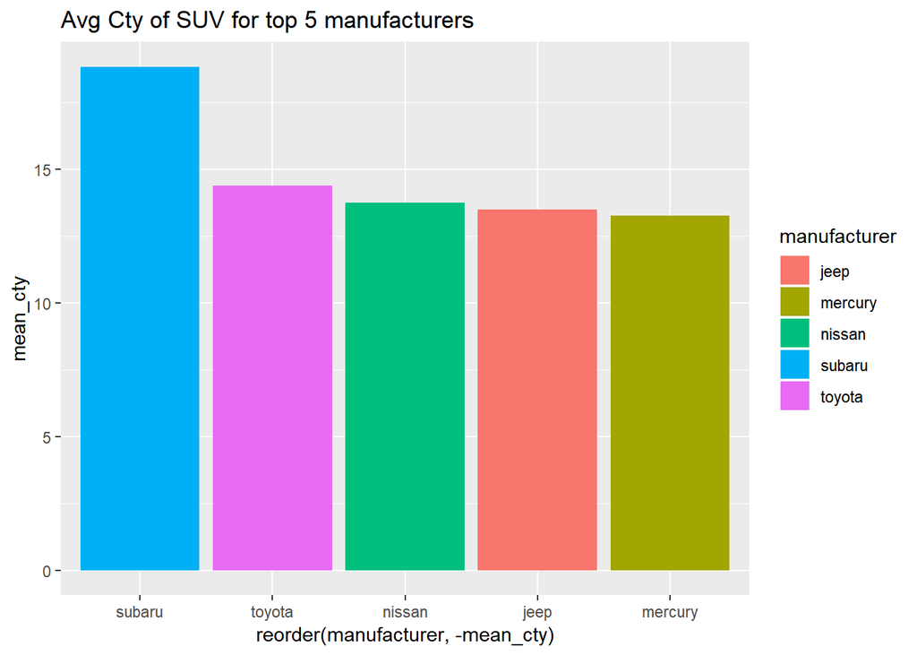

```r
ggplot(suv, aes(x=reorder(manufacturer, -mean_cty), y=mean_cty,
                   fill=manufacturer)) +
  geom_col()+
  ggtitle("Avg Cty of SUV for top 5 manufacturers")
```

#### 4. 자동차 중에서 어떤 class(자동차 종류)가 가장 많은지 알아보려고 합니다. 자동차 종류별 빈도를 표현한 막대 그래프를 만들어 보세요.

- for number of counts (빈도수), no need to actually do ‘count()’ or ‘num’. By plotting the data set, giving x, y and geom_bar(), it automatically calculates & draws it out.

[figure not shown]

```r
class_fq <- sqldf("select class, count(*) as frequency from mpg
      group by class
      order by count(class) desc")

ggplot(class_fq, aes(x= reorder(class, -frequency), y=frequency)) +
  geom_bar(stat='identity', fill = 'cyan', alpha = 0.6) +
  ggtitle("Avg cty of suv comparison for top 5 manufacturers ") +
  theme(axis.text.x = element_text(angle=135, hjust=1, vjust=1,
                                   color='black', size=5))
```

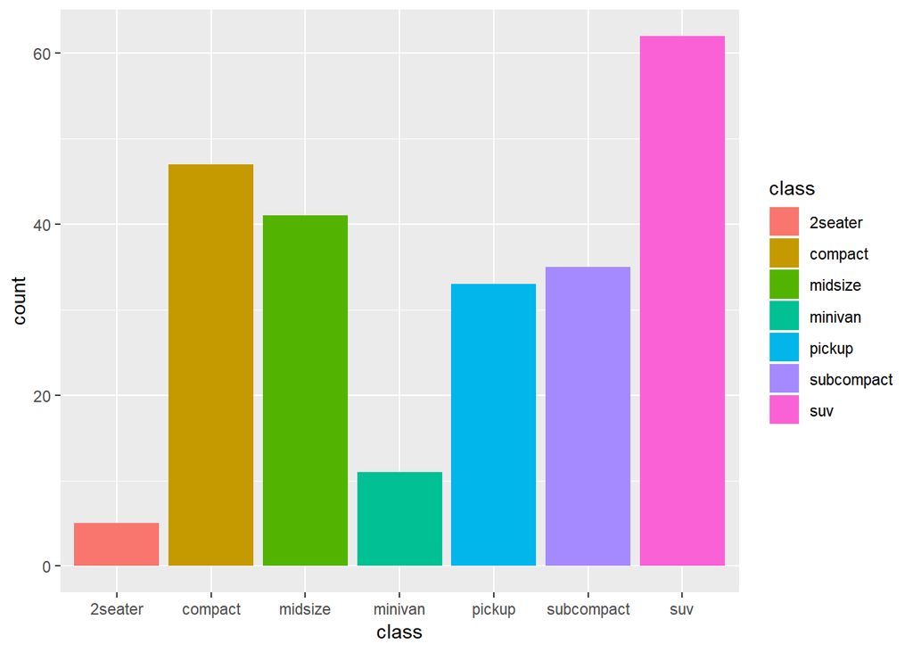

```r
# much simpler. don't even need class_fq

ggplot(mpg, aes(x=class, fill=class)) +
  geom_bar()
```

#### 5. economics 데이터를 이용해서 psavert(개인 저축률)가 시간에 따라서 어떻게 변해왔는지 알아보려고 합니다. 시간에 따른 개인 저축률의 변화를 나타낸 시계열 그래프를 만들어 보세요.

- Time Series graph (시계열 그래프) is as simple as the change pattern of Y vs. time in line graph. No need to complicate

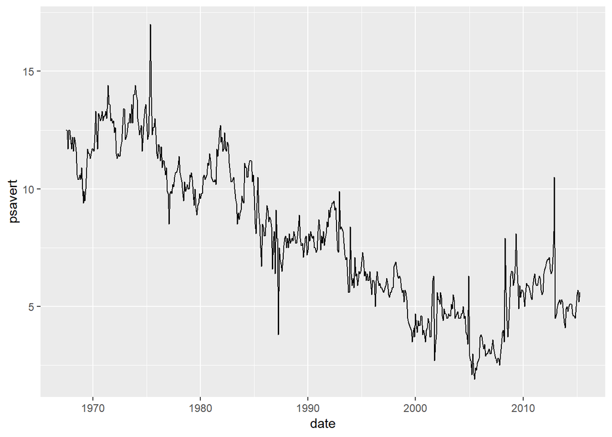

```r
ggplot (economics, aes(x=date, y=psavert)) +
  geom_line()
```

#### 6. class(자동차 종류)가 “compact”, “subcompact”, “suv”인 자동차의 cty(도시 연비)가 어떻게 다른지 비교해보려고 합니다. 세 차종의 cty를 나타낸 상자 그림을 만들어보세요.

- geom_boxplot() automatically calculates/draws IRQ and tails with outlier. No need to filter, summarise extra informations such as median, 1Q, 3Q.

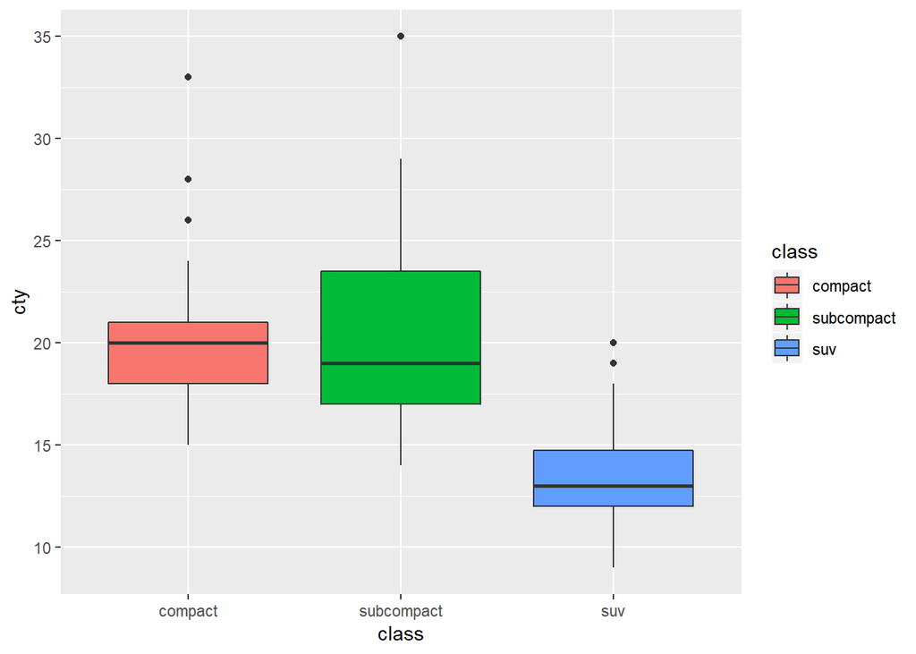

```r
df_3class <- mpg %>%
  filter(class %in% c("compact", "subcompact", "suv"))
ggplot(df_3class, aes(x=class, y=cty, fill=class)) +
  geom_boxplot()
```

#### 7. Diamonds 데이터 셋을 이용하여 다음 문제를 해결하세요. 단, 컬러, 제목, x축, y축 등 그래프를 예쁘게 작성하세요.

#### 1) cut의 돗수를 보여주는 그래프를 작성하세요.

#### 2) cut에 따른 가격의 변화를 보여주는 그래프를 작성하세요.

#### 3) cut과 color에 따른 가격의 변화를 보여주는 그래프를 작성하세요.